# Multi-Criteria Decision Making Using MEGAN Algorithm in mcdabench Package in R

Cagatay Cebeci

5 May 2025

# 1 Introduction

This vignette offers a practical guide on how to perform Multi-Criteria Decision Making (MCDM) using the MEGAN method implemented in the `mcdabench` package within the R environment.

# 2 Load Packages and Data Set

## 2.1 Install and load the package mcdabench

The recent version of the package from CRAN is installed with the following command:

```r
install.packages("mcdabench", dep=TRUE)
```

If you have already installed ‘`mcdabench`’, you can load it into R working environment by using the following command:

```r
library("mcdabench")
```

## 2.2 Data set

This vignette utilizes a sample dataset named `egrids` which is included in the `mcdabench` package. In the decision matrix, there are 12 alternatives which are different energy management strategies or system configurations for optimizing smart grids. There are ten criteria in the decision matrix for evaluating the smart grid in terms of efficiency, reliability, environmental compatibility, and cost-effectiveness. Using Multi-Criteria Decision Analysis (MCDA) methods, the most suitable alternative can be selected.

```r
 data(egrids)
 # Extract the decision matrix, benefit-cost vector and weights

 dmatrix <- egrids$dmat
 bcvec <- egrids$bcvec
 weights <- egrids$weights
 egrids
```

```
## $dmat
##     C1 C2 C3 C4     C5  C6  C7   C8 C9  C10
## G1  85 92 88 75 0.0050 120  98 0.30 95 1.20
## G2  80 90 85 78 0.0070 115  97 0.40 93 1.50
## G3  82 88 87 70 0.0040 110  95 0.35 96 1.10
## G4  78 85 82 80 0.0060 125  99 0.25 94 1.40
## G5  90 95 92 74 0.0055 118  96 0.33 97 1.30
## G6  88 91 89 76 0.0062 112  94 0.28 92 1.40
## G7  81 89 83 79 0.0071 130 100 0.22 98 1.60
## G8  76 83 80 77 0.0065 127  98 0.29 91 1.35
## G9  89 94 90 73 0.0058 122  97 0.27 90 1.25
## G10 87 90 88 72 0.0049 108  93 0.32 89 1.18
## G11 79 84 81 75 0.0067 117  96 0.31 95 1.50
## G12 77 86 79 71 0.0053 105  91 0.26 88 1.22
##
## $bcvec
##  [1]  1  1  1  1 -1 -1 -1 -1 -1 -1
##
## $weights
##   C1   C2   C3   C4   C5   C6   C7   C8   C9  C10
## 0.15 0.12 0.10 0.08 0.07 0.13 0.10 0.08 0.12 0.05
```

# 3 Normalizing Decision Matrix

Before applying MCDA methods, it is often necessary to calcnormal the decision matrix to bring all criteria values to a common scale. Normalization is a crucial step in MCDA to bring different criteria values to a comparable scale. The `calcnormal` function in `mcdabench` provides various normalization techniques. Below, in order to demonstra normalization the decision matrix is calcnormald using the methods “maxmin” and “sum”, and the calcnormald matrices are stored in `nmatrix1` and `nmatrix2`, respectively. Subsequently, the calcnormald colums of these matrices are displayed using `boxplotmcda` function.

```r
nmatrix1 <- calcnormal(dmatrix, bcvec=bcvec, type="maxmin")
nmatrix2 <- calcnormal(dmatrix, bcvec=bcvec, type="sum")
nmatrix3 <- calcnormal(dmatrix, bcvec=bcvec, type="vector")
nmatrix4 <- calcnormal(dmatrix, bcvec=bcvec, type="zavadskas")
nmatrix5 <- calcnormal(dmatrix, bcvec=bcvec, type="ratio")
nmatrix6 <- calcnormal(dmatrix, bcvec=bcvec, type="enacc")
```

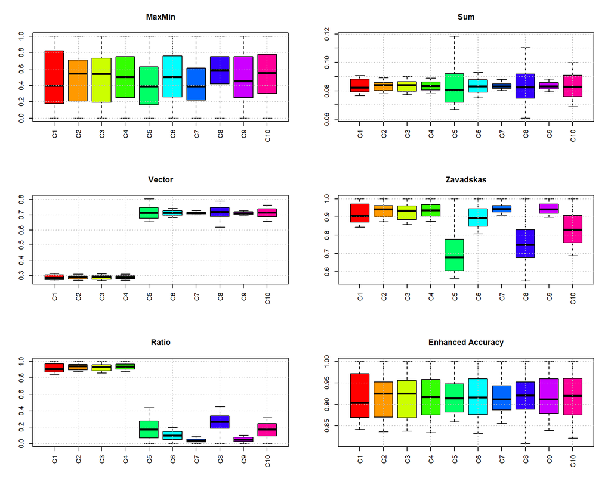

```r
opar <- par(mfrow=c(3,2))
boxplotmcda(nmatrix1, mt="MaxMin")
boxplotmcda(nmatrix2, mt="Sum")
boxplotmcda(nmatrix3, mt="Vector")
boxplotmcda(nmatrix4, mt="Zavadskas")
boxplotmcda(nmatrix5, mt="Ratio")
boxplotmcda(nmatrix6, mt="Enhanced Accuracy")
```

```r
par(opar)
```

The choice of normalization method significantly affects the scale and distribution of the calcnormald data. The boxplots visually highlight the difference in the scaling produced by the normalization methods. Based-on the example above:

MaxMin normalization scales all values within the range of 0 to 1, as clearly indicated by the y-axis. The boxplots demonstrate a relatively wide spread of normalized values for each criterion, reflecting the full range of original data within this new scale.

In stark contrast, theSum Normalization method shows a much smaller range and a higher concentration of values within a narrow band (e.g., around 0.08 to 0.09 for most criteria). This suggests that the Sum method heavily compresses the data, making the distinctions between values less pronounced on a relative scale compared to MaxMin.

Zavadskas-Turskis Normalization tends to compress the normalized values towards the higher end of the scale (closer to 1), with most criteria showing a relatively high mean. While it exhibits noticeable variability across criteria, the overall trend is to maintain values at a higher relative level compared to methods like Sum or Vector.

Ratio or (Max) Normalization presents a more varied and sometimes extreme impact on the data scale. While some criteria (like C1-C4) are scaled close to 1, others (like C5, C6, C9, and C10) are heavily compressed towards very low values (closer to 0). This suggests that Ratio normalization emphasizes differences more prominently when original values are disparate, pushing smaller values to a much lower relative scale and larger values towards the maximum.

# 4 Calculation of Weights

The choice of objective weighting method has a substantial impact on the determined importance of each criterion. The weighting methods further highlights the diversity of approaches and the importance of selecting a method that aligns with the specific characteristics and objectives of the multi-criteria decision analysis.

The following code chunk calculates the weights for the criteria using various weighting methods. The `wmatrix` output displays the specific weight assigned to each criterion by each of these methods. Parallel Coordinate Plots are effective for comparing the profiles of many options across multiple dimensions simultaneously, allowing for the assessment of similarities, dissimilarities, and the identification of underlying patterns. For this reason, the visualization provided by `parcorplot` helps for understand and compare these different weighting profiles.

```r
nmatrix <- calcnormal(dmatrix, bcvec, type="vector")
critwei <- calcweights(nmatrix, bcvec=bcvec, type="critic")
entwei <- calcweights(nmatrix, bcvec=bcvec, type="entropy")
equwei <- calcweights(nmatrix, bcvec=bcvec, type="equal")
giniwei <- calcweights(nmatrix, bcvec=bcvec, type="gini")
sdevwei <- calcweights(nmatrix, bcvec=bcvec, type="sdev")
merecwei <- calcweights(nmatrix, bcvec=bcvec, type="merec")
mpsiwei <- calcweights(nmatrix, bcvec=bcvec, type="mpsi")
geomwei <- calcweights(nmatrix, bcvec=bcvec, type="geom")
rocwei <- calcweights(nmatrix, bcvec=bcvec, type="roc")
rswei <- calcweights(nmatrix, bcvec=bcvec, type="rs")

wmatrix <- cbind(Equal=equwei, Merec=merecwei, Geometric=geomwei, Gini=giniwei,
           Critic=critwei, Mpsi=mpsiwei, StdDev=sdevwei, Rs=rswei, Roc=rocwei, Entropy=entwei)
print(round(wmatrix, 3))
```

```
##     Equal Merec Geometric  Gini Critic  Mpsi StdDev    Rs   Roc Entropy
## C1    0.1 0.098     0.086 0.142  0.066 0.128  0.079 0.182 0.341   0.168
## C2    0.1 0.099     0.094 0.103  0.051 0.106  0.057 0.164 0.171   0.089
## C3    0.1 0.099     0.091 0.119  0.057 0.111  0.066 0.145 0.114   0.119
## C4    0.1 0.100     0.098 0.101  0.090 0.103  0.056 0.127 0.085   0.084
## C5    0.1 0.103     0.125 0.152  0.180 0.094  0.210 0.109 0.068   0.192
## C6    0.1 0.100     0.098 0.064  0.079 0.100  0.088 0.091 0.057   0.034
## C7    0.1 0.102     0.122 0.026  0.032 0.085  0.036 0.073 0.049   0.006
## C8    0.1 0.099     0.091 0.151  0.273 0.074  0.212 0.055 0.043   0.200
## C9    0.1 0.100     0.101 0.033  0.046 0.106  0.046 0.036 0.038   0.009
## C10   0.1 0.099     0.094 0.109  0.125 0.094  0.150 0.018 0.034   0.099
```

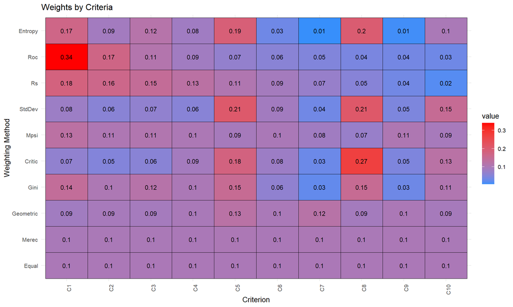

```r
corplot(wmatrix, colpal=c("orange", "dodgerblue","red"), xlab="Criterion", ylab="Weighting Method", title="Weights by Criteria", shape="square")
```

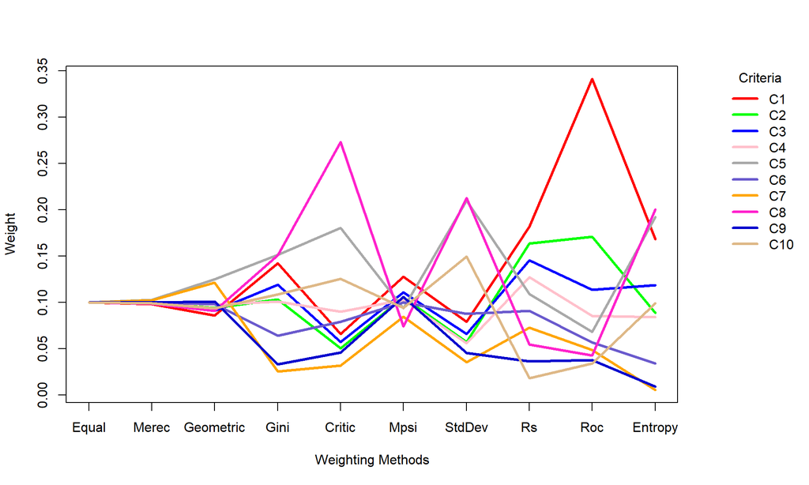

```r
parcorplot(wmatrix, xl="Weighting Methods", yl="Weight", lt="Criteria")
```

The parallel coordinate plot, alongside the provided weight matrix, illustrates the weights assigned to ten criteria (C1 through C10) by ten distinct objective weighting methods: Equal, Merec, Geometric, Gini, Critic, Mpsi, StdDev (Standard Deviation), Rs, Roc, and Entropy. Each criterion is represented by a colored line, and its vertical position along the x-axis indicates the weight allocated by the corresponding weighting method.

# 5 Run MEGAN with Default Parameters

The following code snippet runs the MEGAN algorithm using the `dmatrix` decision matrix and the `bcvec` benefit-cost vector. For this execution, Gini weighting and MaxMin normalization are explicitly specified. Notably, while `megan` intrinsically uses Gini weighting and MaxMin normalization, the function is flexible, allowing the user to override these defaults by specifying pre-calculated weights and alternative normalization methods. The results are stored in `resmegan_1`. The structure of this result object, as displayed by the `str` function, contains various internal components of the MEGAN calculation.

```r
resmegan_1 <- megan(dmatrix, bcvec=bcvec, weights="gini", normethod="maxmin", thr=0, tht=NULL)
str(resmegan_1)
```

```
## List of 10
##  $ dmatrix       : num [1:12, 1:10] 85 80 82 78 90 88 81 76 89 87 ...
##   ..- attr(*, "dimnames")=List of 2
##   .. ..$ : chr [1:12] "G1" "G2" "G3" "G4" ...
##   .. ..$ : chr [1:10] "C1" "C2" "C3" "C4" ...
##  $ wmatrix       : num [1:12, 1:10] 0.0741 0.0329 0.0494 0.0165 0.1152 ...
##   ..- attr(*, "dimnames")=List of 2
##   .. ..$ : chr [1:12] "G1" "G2" "G3" "G4" ...
##   .. ..$ : chr [1:10] "C1" "C2" "C3" "C4" ...
##  $ minvec        : Named num [1:10] 0 0 0 0 0.114 ...
##   ..- attr(*, "names")= chr [1:10] "C1" "C2" "C3" "C4" ...
##  $ distmatrix    : num [1:12, 1:10] 0.0741 0.0329 0.0494 0.0165 0.1152 ...
##   ..- attr(*, "dimnames")=List of 2
##   .. ..$ : chr [1:12] "G1" "G2" "G3" "G4" ...
##   .. ..$ : chr [1:10] "C1" "C2" "C3" "C4" ...
##  $ ndistmatrix   : num [1:12, 1:10] 0.643 0.286 0.429 0.143 1 ...
##   ..- attr(*, "dimnames")=List of 2
##   .. ..$ : chr [1:12] "G1" "G2" "G3" "G4" ...
##   .. ..$ : chr [1:10] "C1" "C2" "C3" "C4" ...
##  $ distrowsums   : Named num [1:12] 5.63 6.46 3.63 5.24 6.87 ...
##   ..- attr(*, "names")= chr [1:12] "G1" "G2" "G3" "G4" ...
##  $ superiority   : Named num [1:12] 332 396 178 302 427 326 442 240 337 185 ...
##   ..- attr(*, "names")= chr [1:12] "G1" "G2" "G3" "G4" ...
##  $ threshmethod  : chr "user"
##  $ thresholdvalue: num 0
##  $ rank          : Named num [1:12] 5 3 11 7 2 6 1 9 4 10 ...
##   ..- attr(*, "names")= chr [1:12] "G1" "G2" "G3" "G4" ...
```

In the `resmegan_1` above, MEGAN’s result object, the `superiority` component contains the superiority of alternatives as percentages over the worst alrnative. The ranking result for alternatives is stored in the component of `rank`.

```r
# Superiority scores
 superiority <- resmegan_1$superiority
 print(superiority)
```

```
##  G1  G2  G3  G4  G5  G6  G7  G8  G9 G10 G11 G12
## 332 396 178 302 427 326 442 240 337 185 273   0
```

```r
# Ranking of Alternatives
 rank <- resmegan_1$rank
 print(rank)
```

```
##  G1  G2  G3  G4  G5  G6  G7  G8  G9 G10 G11 G12
##   5   3  11   7   2   6   1   9   4  10   8  12
```

As seen in the output, the `superiority` vector presents the superiority scores for alternatives, ranging from `0` to `442`. The worst alternative, `G12v, consistently has a score of`0v. Higher scores indicate greater overall superiority. The rank vector provides the final ranks of the alternatives based on their superiority scores. Lower numbers indicate a better (higher) rank. In this run, `G7` (superiority: `442`, rank: `1`) is identified as the best alternative, while `G12v (superiority:`0`, rank:`12`) is determined to be the worst-performing alternative.

MEGAN stands out as a novelMCDA algorithm characterized by its function-free approach and relative insensitivity to weight variations. While the core MEGAN function was executed above using default parameters, the following code chunk demonstrates MEGAN’s gradual weighting algorithm. This variant evaluates the decision matrix with weights that are systematically varied (either increasing or decreasing) across criteria, using the same initial decision matrix and a specific set of weights (in this case, `giniwei` and `maxmin` normalization from the previous megan example). This approach helps to further explore the robustness and behavior of the MEGAN method under changing preference structures.

While the core MEGAN function was executed above using specific Gini weighting and MaxMin normalization, the following code chunk demonstrates MEGAN’s gradual weighting algorithm. This variant evaluates the decision matrix with weights that are systematically varied (either increasing or decreasing) across criteria, using the same initial decision matrix and a specific set of `weights` (in this case, `giniwe` and `"maxmin"` normalization from the previous `megan` example). This approach helps to further explore the robustness and behavior of the MEGAN method under changing preference structures. The `ratepar` sequence defines the increments for these gradual weight changes.

```r
ratepar <- seq(0.01, 0.5, 0.05)
giniwei <- calcweights(nmatrix, bcvec=bcvec, type="gini")
resmegan_2 <- megan2(dmatrix, bcvec=bcvec, weights=giniwei, normethod="maxmin",
  weimethod="gradual", rp=ratepar, thr=0)

 str(resmegan_2)
```

```
## List of 3
##  $ weimat : num [1:101, 1:10] 0.142 0.141 0.134 0.127 0.119 ...
##   ..- attr(*, "dimnames")=List of 2
##   .. ..$ : chr [1:101] "init" "C1-1%" "C1-6%" "C1-11%" ...
##   .. ..$ : chr [1:10] "C1" "C2" "C3" "C4" ...
##  $ rankmat: num [1:101, 1:12] 5 5 5 5 5 5 5 5 5 5 ...
##   ..- attr(*, "dimnames")=List of 2
##   .. ..$ : chr [1:101] "init" "C1-1%" "C1-6%" "C1-11%" ...
##   .. ..$ : chr [1:12] "G1" "G2" "G3" "G4" ...
##  $ rank   : Named num [1:12] 5 3 11 7 2 6 1 9 4 10 ...
##   ..- attr(*, "names")= chr [1:12] "G1" "G2" "G3" "G4" ...
```

```r
 rank <- resmegan_2$rank
 print(rank)
```

```
##  G1  G2  G3  G4  G5  G6  G7  G8  G9 G10 G11 G12
##   5   3  11   7   2   6   1   9   4  10   8  12
```

In this specific gradual weighting scenario with Gini weights and MaxMin normalization, the final ranking derived by ‘megan2’ remains identical to the initial ‘megan’ run. ‘G7’ (rank: ‘1’) is still the top-ranked alternative, and ‘G12’ (rank: ‘12’) remains the lowest. This consistency suggests that for this particular dataset and initial Gini weights, the MEGAN algorithm demonstrates robustness to the tested range of gradual weight changes. This observation further supports MEGAN’s characteristic insensitivity to weight variations, at least within the explored ratepar range.

# 6 Different Types of Thresholds

A classic ranking typically states, “Alternative A outranks Alternative B,” but it often fails to answer a more nuanced question: “By how much is Alternative A superior?” MEGAN addresses this by providing superiority percentages. For example, in the result of previous run (`resmegan_1`), `G12` has the minimum superiority score (`0`), indicating it is the worst-performing alternative relative to others in the set. Conversely, `G7` exhibits the highest superiority score (`442`), suggesting it is 442% “higher” than the base (worst) alternative, `G12`. For instance, Alternative `G1` has a superiority score of `332`, and Alternative `G6` has `326`. Based on these raw superiority values, both `G1` and `G6` clearly outrank the base alternative `G12`. However, the difference between their individual superiority scores (`332` vs. `326`) is quite small. A traditional ranking, based on strict numerical order, would simply place `G1` above `G6` (`G1` > `G6`).

However, if these small differences were evaluated against a custom threshold, `G1` and `G6` could potentially receive the same rank. Specifically, if the difference in superiority scores between two consecutive alternatives falls below a defined threshold, they are treated as having the same rank, implying no statistically or practically significant preference between them. The rank values in MEGAN are calculated precisely in this manner, based on a threshold value passed to the `thr` argument or derived from the `tht` argument. Consequently, alternatives whose superiority differences fall below this threshold receive the same rank.

MEGAN offers flexibility in defining these thresholds:

- `thr` argument: Allows the user to specify a direct numerical threshold. If `thr=0`, no difference is tolerated, and a strict ranking is maintained (unless values are exactly identical).
- `tht` argument: When `thr=NULL`, the `tht` argument can be used to define a threshold based on statistical properties of the differences in superiority scores:
  - `"p5"`: Uses the 5th percentile of differences as the default threshold level.
  - `"p25"` (or `"Q1"`): Uses the 25th percentile (first quartile) of differences.
  - `"sdev"`: Uses the standard deviation of differences.

In the following code snippet, MEGAN is run with different levels and types of thresholds to demonstrate their impact on the final ranking. The `giniwei` (Gini weights) are used for consistency.

```r
rankt0 <- megan(dmatrix, bcvec=bcvec, weights=giniwei, thr=0)$rank
rankt10 <- megan(dmatrix, bcvec=bcvec, weights=giniwei, thr=10)$rank
rankp5 <- megan(dmatrix, bcvec=bcvec, weights=giniwei, thr=NULL, tht="p5")$rank
rankp25 <- megan(dmatrix, bcvec=bcvec, weights=giniwei, thr=NULL, tht="p25")$rank
ranksdev <- megan(dmatrix, bcvec=bcvec, weights=giniwei, thr=NULL, tht="sdev")$rank

meganranks_2 <- cbind(T0=rankt0, T10=rankt10, P5=rankp5, P25=rankp25, SD=ranksdev)
meganranks_2 <- t(meganranks_2)
print(meganranks_2)
```

```
##      G1  G2 G3  G4 G5  G6   G7 G8  G9 G10  G11 G12
## T0  5.5 9.0  7 8.0  4 3.0 11.0 10 2.0   1 12.0 5.5
## T10 6.0 8.5  6 8.5  3 3.0 11.0 11 3.0   1 11.0 6.0
## P5  5.5 9.0  7 8.0  4 3.0 11.0 10 2.0   1 12.0 5.5
## P25 5.5 8.5  7 8.5  4 2.5 11.5 10 2.5   1 11.5 5.5
## SD  5.5 8.5  7 8.5  4 2.5 11.0 11 2.5   1 11.0 5.5
```

Finally, a heatmap is generated to visually compare these different ranking profiles across alternatives:

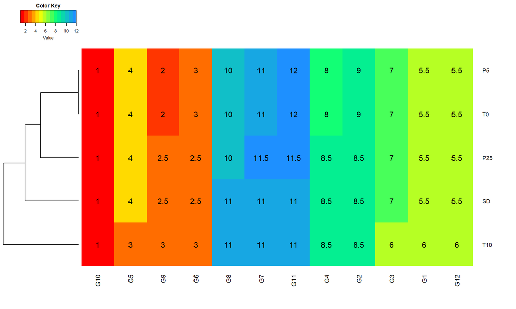

```r
rankheatmap(meganranks_2, colpal=1, cellnotes=TRUE, tcol="black", dendro="row")
```

In addition to the ranking variations, it is crucial to understand the actual numerical values of the thresholds being applied. The `thresholdval` component of the `megan` function’s output allows us to retrieve these.

In the example, the assigned and computed thresholds can be shown using the code chunk below:

```r
thr0 <- megan(dmatrix, bcvec=bcvec, weights=giniwei, thr=0)$thresholdval
thr10 <- megan(dmatrix, bcvec=bcvec, weights=giniwei, thr=10)$thresholdval
thrp5 <- megan(dmatrix, bcvec=bcvec, weights=giniwei, thr=NULL, tht="p5")$thresholdval
thrp25 <- megan(dmatrix, bcvec=bcvec, weights=giniwei, thr=NULL, tht="p25")$thresholdval
thrsdev <- megan(dmatrix, bcvec=bcvec, weights=giniwei, thr=NULL, tht="sdev")$thresholdval
thrp5 <- unname(thrp5); thrp25 <- unname(thrp25)

meganthresholds <- c(T0=thr0, T10=thr10, P5=thrp5, P25=thrp25, SD=thrsdev)
print(meganthresholds)
```

```
##        T0       T10        P5       P25        SD
##  0.000000 10.000000  0.500000  1.000000  7.166209
```

This output clearly shows the specific numerical thresholds that were used for each ranking scenario:

- T0: A threshold of 0, meaning only exact matches receive the same rank.
- T10: A fixed user-defined threshold of 10.
- P5: A calculated threshold of 0.5, representing the 5th percentile of differences in superiority scores.
- P25: A calculated threshold of 1.0, representing the 25th percentile (or first quartile) of differences.
- SD: A calculated threshold of approximately 7.17, representing the standard deviation of differences.

These explicit threshold values provide critical context for interpreting the meganranks_2 output, demonstrating how subtle differences in threshold definition can lead to distinct grouping of alternatives and variations in their final ranks.

# 7 Apply MEGAN with Different Weighting Methods

```r
thrval <- 0L
thtmet <- "p5"
critrank <- megan(dmatrix, bcvec=bcvec, weights=critwei, thr=thrval, tht=thtmet)$rank
entrank <- megan(dmatrix, bcvec=bcvec, weights=entwei, thr=thrval, tht=thtmet)$rank
equrank <- megan(dmatrix, bcvec=bcvec, weights=equwei, thr=thrval, tht=thtmet)$rank
ginirank <- megan(dmatrix, bcvec=bcvec, weights=giniwei, thr=thrval, tht=thtmet)$rank
mpsirank <- megan(dmatrix, bcvec=bcvec, weights=mpsiwei, thr=thrval, tht=thtmet)$rank
sdevrank <- megan(dmatrix, bcvec=bcvec, weights=sdevwei, thr=thrval, tht=thtmet)$rank
geomrank <- megan(dmatrix, bcvec=bcvec, weights=geomwei, thr=thrval, tht=thtmet)$rank
merecrank <- megan(dmatrix, bcvec=bcvec, weights=merecwei, thr=thrval, tht=thtmet)$rank

meganranks_3 <- cbind(Equal=equrank, Critic=critrank, StdDev=sdevrank, Gini=ginirank,
  Geometric=geomrank, Merec=merecrank, Mpsi=mpsirank, Entropy=entrank)
rownames(meganranks_3) <- rownames(dmatrix)
print(meganranks_3)
```

```
##     Equal Critic StdDev Gini Geometric Merec Mpsi Entropy
## G1    5.5    5.5    5.5  5.5       5.5   5.5  5.5     5.5
## G2    9.0    9.0    9.0  9.0       9.0   9.0  9.0     9.0
## G3    7.0    7.0    7.0  7.0       7.0   7.0  7.0     7.0
## G4    8.0    8.0    8.0  8.0       8.0   8.0  8.0     8.0
## G5    4.0    4.0    4.0  4.0       4.0   4.0  4.0     4.0
## G6    3.0    3.0    3.0  3.0       3.0   3.0  3.0     3.0
## G7   11.0   11.0   11.0 11.0      11.0  11.0 11.0    11.0
## G8   10.0   10.0   10.0 10.0      10.0  10.0 10.0    10.0
## G9    2.0    2.0    2.0  2.0       2.0   2.0  2.0     2.0
## G10   1.0    1.0    1.0  1.0       1.0   1.0  1.0     1.0
## G11  12.0   12.0   12.0 12.0      12.0  12.0 12.0    12.0
## G12   5.5    5.5    5.5  5.5       5.5   5.5  5.5     5.5
```

```r
respref <- rankaggregate(t(meganranks_3), topk=1)

print(respref$preference_table)  # Preference table
```

```
##     Method                                                   Outranking
## 1    TOPK1 G10 > G1 = G2 = G3 = G4 = G5 = G6 = G7 = G8 = G9 = G11 = G12
## 2  RANKSUM G10 > G9 > G6 > G5 > G1 = G12 > G3 > G4 > G2 > G8 > G7 > G11
## 3   MEDIAN G10 > G9 > G6 > G5 > G1 = G12 > G3 > G4 > G2 > G8 > G7 > G11
## 4 BORDACNT G10 > G9 > G6 > G5 > G1 = G12 > G3 > G4 > G2 > G8 > G7 > G11
## 5 COPELAND G10 > G9 > G6 > G5 > G1 = G12 > G3 > G4 > G2 > G8 > G7 > G11
## 6   KEMYNG G10 > G9 > G6 > G5 > G1 = G12 > G3 > G4 > G2 > G8 > G7 > G11
## 7   MARKOV G10 > G9 > G6 > G5 > G1 = G12 > G3 > G4 > G2 > G8 > G7 > G11
```

```r
print(respref$preference_ranking) # Preference ranking
```

```
##           G1 G2 G3 G4 G5 G6 G7 G8 G9 G10 G11 G12
## TOPK1    7.0  7  7  7  7  7  7  7  7   1   7 7.0
## RANKSUM  5.5  9  7  8  4  3 11 10  2   1  12 5.5
## MEDIAN   5.5  9  7  8  4  3 11 10  2   1  12 5.5
## BORDACNT 5.5  9  7  8  4  3 11 10  2   1  12 5.5
## COPELAND 5.5  9  7  8  4  3 11 10  2   1  12 5.5
## KEMYNG   5.5  9  7  8  4  3 11 10  2   1  12 5.5
## MARKOV   5.5  9  7  8  4  3 11 10  2   1  12 5.5
```

To visually confirm this remarkable consistency, a heatmap of these rankings is generated.

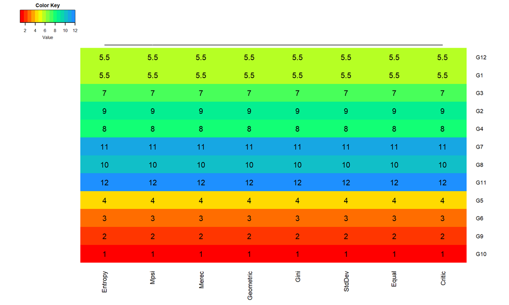

```r
rankheatmap(meganranks_3, colpal=1, cellnotes=TRUE, tcol="black", dendro="column")
```

To understand the relationships between the rankings produced by different weighting methods, we can perform a Principal Component Analysis (PCA) on the meganranks_3 matrix. This helps visualize the similarities and differences in how each weighting method ranks the alternatives. The `rankpca` function is used for this purpose, with `biplot=TRUE` to show both the alternatives and the weighting methods on the same plot.

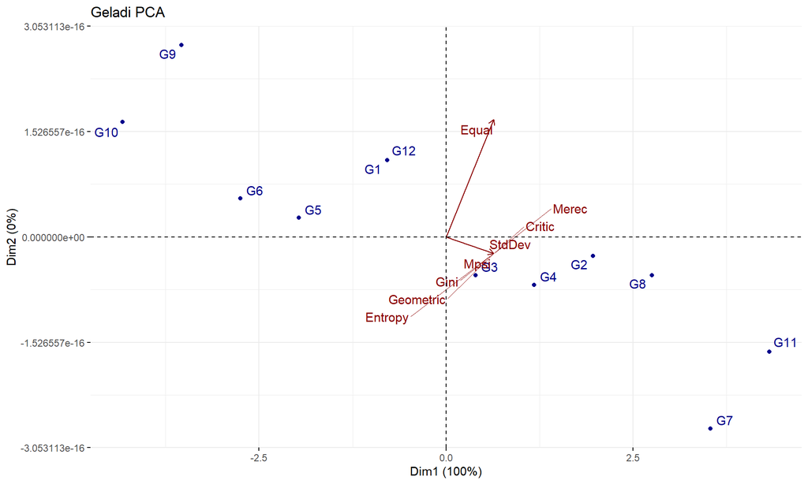

```r
a <- rankpca(meganranks_3, biplot=TRUE, reverse=FALSE)
```

# Comparing Normalization Methods using GINI Weights While the previous section demonstrated MEGAN’s remarkable insensitivity to various objective weighting methods, it’s equally important to assess its behavior under different normalization techniques. Normalization is a critical preprocessing step in MCDA that transforms criteria values to a common scale, and its choice can significantly influence the final outcome in many algorithms.

```r
thrval <- NULL
thtmet <- "p5"
enhrank <- megan(dmatrix, bcvec=bcvec, weights=giniwei, normethod="enhanced", thr=thrval, tht=thtmet)$rank
ratiorank <- megan(dmatrix, bcvec=bcvec, weights=giniwei, normethod="ratio", thr=thrval, tht=thtmet)$rank
maxminrank <- megan(dmatrix, bcvec=bcvec, weights=giniwei, normethod="maxmin", thr=thrval, tht=thtmet)$rank
sumrank <- megan(dmatrix, bcvec=bcvec, weights=giniwei, normethod="sum", thr=thrval, tht=thtmet)$rank
vecrank <- megan(dmatrix, bcvec=bcvec, weights=giniwei, normethod="vector", thr=thrval, tht=thtmet)$rank
zavrank <- megan(dmatrix, bcvec=bcvec, weights=giniwei, normethod="zavadskas", thr=thrval, tht=thtmet)$rank
meganranks_4 <- cbind(Enhanced=enhrank, MaxMin=maxminrank,
   Sum=sumrank, Ratio=ratiorank, Vector=vecrank, Zavadskas=zavrank)
rownames(meganranks_4) <- rownames(dmatrix)
print(meganranks_4)
```

```
##     Enhanced MaxMin  Sum Ratio Vector Zavadskas
## G1       4.5    4.5  4.5   4.5    4.5       4.5
## G2       3.0    3.0  3.0   3.0    3.0       3.0
## G3      11.0   11.0 11.0  11.0   11.0      11.0
## G4       7.0    7.0  7.0   7.0    7.0       7.0
## G5       2.0    2.0  1.0   2.0    2.0       1.0
## G6       6.0    6.0  6.0   6.0    6.0       6.0
## G7       1.0    1.0  2.0   1.0    1.0       2.0
## G8       9.0    9.0  9.0   9.0    9.0       9.0
## G9       4.5    4.5  4.5   4.5    4.5       4.5
## G10     10.0   10.0 10.0  10.0   10.0      10.0
## G11      8.0    8.0  8.0   8.0    8.0       8.0
## G12     12.0   12.0 12.0  12.0   12.0      12.0
```

Unlike the consistency observed across different weighting methods, the `meganranks_4` matrix reveals some variations in rankings across different normalization methods. While many alternatives retain their ranks across methods (e.g., G3, G4, G8, G10, G11, G12 show perfect consistency), slight shifts occur for others. For instance:

- G5 is ranked 1st by ‘Sum’ and ‘Zavadskas’ methods, but 2nd by ‘Enhanced’, ‘MaxMin’, ‘Ratio’, and ‘Vector’.
- G7 is ranked 1st by ‘Enhanced’, ‘MaxMin’, ‘Ratio’, and ‘Vector’, but 2nd by ‘Sum’ and ‘Zavadskas’.
- G1 and G9 maintain a consistent tied rank of 4.5 across all normalization methods.

This pattern suggests that MEGAN’s ranking, while robust to weighting, may slightly be influenced by the choice of normalization method. This highlights the importance of carefully selecting an appropriate normalization technique, as it can subtly alter the relative performances of alternatives before they are evaluated by MEGAN’s core mechanism.

To visually analyze these differences and similarities, a heatmap of the rankings is generated:

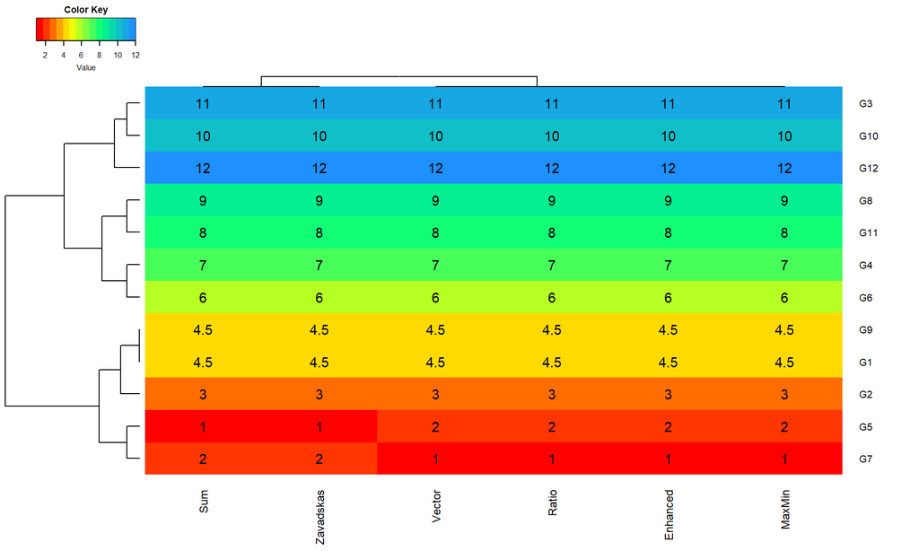

```r
rankheatmap(meganranks_4, colpal=1, cellnotes=TRUE, tcol="black", dendro="both")
```

The heatmap visually confirms the observed variations. While clusters of consistent ranks exist, the distinct columns for ‘Sum’ and ‘Zavadskas’ (particularly for G5 and G7) demonstrate how different normalization scales can lead to different relative positions for closely performing alternatives. The dendrograms would further highlight the clustering of similar ranking profiles.

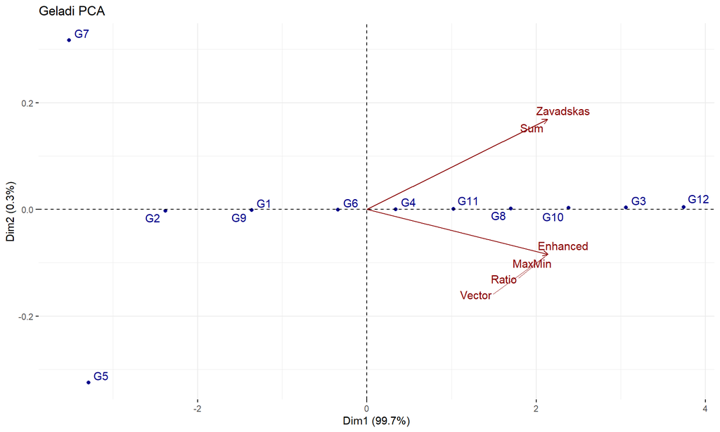

```r
a <- rankpca(meganranks_4, biplot=TRUE, reverse=FALSE)
```

To derive a single, consolidated preference order from these varied rankings, we again employ the rankaggregate function. This step is particularly valuable here, as the individual normalization methods did not yield perfectly identical results.

```r
respref <- rankaggregate(t(meganranks_4), topk=1)
print(respref$preference_table)  # Outranking table
```

```
##     Method                                                   Outranking
## 1    TOPK1 G7 > G5 > G1 = G2 = G3 = G4 = G6 = G8 = G9 = G10 = G11 = G12
## 2  RANKSUM G7 > G5 > G2 > G1 = G9 > G6 > G4 > G11 > G8 > G10 > G3 > G12
## 3   MEDIAN G7 > G5 > G2 > G1 = G9 > G6 > G4 > G11 > G8 > G10 > G3 > G12
## 4 BORDACNT G7 > G5 > G2 > G1 = G9 > G6 > G4 > G11 > G8 > G10 > G3 > G12
## 5 COPELAND G7 > G5 > G2 > G1 = G9 > G6 > G4 > G11 > G8 > G10 > G3 > G12
## 6   KEMYNG G7 > G5 > G2 > G1 = G9 > G6 > G4 > G11 > G8 > G10 > G3 > G12
## 7   MARKOV G5 > G7 > G2 > G1 = G9 > G6 > G4 > G11 > G8 > G10 > G3 > G12
```

```r
print(respref$preference_ranking)  # Outranking flow
```

```
##           G1  G2   G3  G4 G5  G6 G7  G8  G9  G10 G11  G12
## TOPK1    7.5 7.5  7.5 7.5  2 7.5  1 7.5 7.5  7.5 7.5  7.5
## RANKSUM  4.5 3.0 11.0 7.0  2 6.0  1 9.0 4.5 10.0 8.0 12.0
## MEDIAN   4.5 3.0 11.0 7.0  2 6.0  1 9.0 4.5 10.0 8.0 12.0
## BORDACNT 4.5 3.0 11.0 7.0  2 6.0  1 9.0 4.5 10.0 8.0 12.0
## COPELAND 4.5 3.0 11.0 7.0  2 6.0  1 9.0 4.5 10.0 8.0 12.0
## KEMYNG   4.5 3.0 11.0 7.0  2 6.0  1 9.0 4.5 10.0 8.0 12.0
## MARKOV   4.5 3.0 11.0 7.0  1 6.0  2 9.0 4.5 10.0 8.0 12.0
```

The aggregation results reflect the slight variations observed. The preference_table and preference_ranking show that for most aggregation methods (RANKSUM, MEDIAN, BORDACNT, COPELAND, KEMYNG), `G7` is the consensus top-ranked alternative (rank 1), closely followed by `G5` (rank 2) and `G2` (rank 3). Notably, the MARKOV method, while still placing `G5` and `G7` at the top, swaps their positions, ranking `G5` as 1st and `G7` as 2nd. This slight disagreement for the top two alternatives is a direct consequence of the differing individual rankings obtained from the normalization methods.

# 8 Weights Sensitivity Analysis

Beyond applying different static weighting methods, it’s crucial to assess an MCDA algorithm’s sensitivity to gradual changes in criterion weights. This type of sensitivity analysis helps determine how robust the ranking results are to minor fluctuations or uncertainties in the assigned importance of criteria. The `weisana` (weighting sensitivity analysis) function from the `mcdabench` package facilitates this by systematically varying individual criterion weights and observing the impact on the final ranking.

In this example, we perform a gradual weighting sensitivity analysis using the `critwei` (Critic weights) as the base. The `weipars` argument defines the range of gradual changes: increments of 0.01, 0.05, 0.10, and decrements of -0.01, -0.05, -0.10. The `mcdamethod` is set to `megan`, with `methodpars` specifying `thr=0` (no threshold for differences, implying a strict ranking unless values are identical).

```r
mp <- list(thr=0)
wp <- list(rp = c(0.01, 0.05, 0.10, -0.01, -0.05, -0.10))
megangrawei <- weisana(dmatrix = dmatrix, bcvec = bcvec, weights=critwei,
     weimethod = "gradual", weipars = wp,
     mcdamethod = megan, methodpars = mp,
     sensplot=FALSE)
rankmat <- megangrawei$ranking_matrix    # Ranking matrix
senstable <- megangrawei$sensitivity_table # Different rankings summary table
head(rankmat)  # Rank matrix
```

```
##         G1 G2 G3 G4 G5 G6 G7 G8 G9 G10 G11 G12
## init   5.5  9  7  8  4  3 11 10  2   1  12 5.5
## C1-1%  5.5  9  7  8  4  3 11 10  2   1  12 5.5
## C1-5%  5.5  9  7  8  4  3 11 10  2   1  12 5.5
## C1-10% 5.5  9  7  8  4  3 11 10  2   1  12 5.5
## C1--1% 5.5  9  7  8  4  3 11 10  2   1  12 5.5
## C1--5% 5.5  9  7  8  4  3 11 10  2   1  12 5.5
```

```r
print(senstable)
```

```
##                                  Pattern Count Percent
## Ranking_1 5.5,9,7,8,4,3,11,10,2,1,12,5.5    61     100
```

The `weisana` function returns two key components for analysis: `ranking_matrix` (containing the ranks for each variation) and `sensitivity_table` (summarizing distinct ranking patterns).

The `rankmat` output shows the ranks of alternatives for the initial (`init`) weights and for various gradual changes applied to each criterion (e.g., `C1-1%`, `C1-5%`, etc.). Remarkably, the `sensitivity_table` indicates only one distinct ranking pattern (`Ranking_1`) throughout the entire sensitivity analysis, accounting for 100% of the scenarios (61 total scenarios, representing gradual changes for each of the 10 criteria in both increasing and decreasing directions, plus the initial state). This finding further underscores MEGAN’s strong robustness to gradual changes in criterion weights. Regardless of the small increments or decrements applied to individual criterion weights, the final ranking order of alternatives remains unchanged.

A heatmap of the rankmat visually confirms this exceptional consistency.

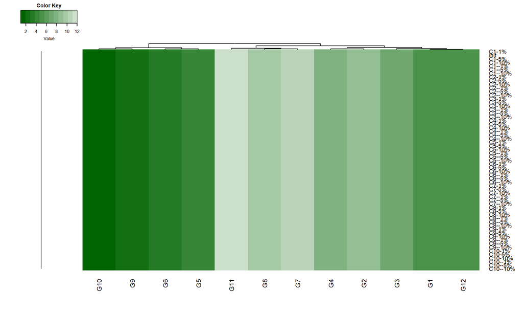

```r
rankheatmap(rankmat, colpal=4, cellnotes=FALSE, tcol="black", dendro="both")
```

```r
a <- rankpca(rankmat, biplot=TRUE, reverse=FALSE)
```

[output not shown]

# 9 Conclusions

Below, we can offer a general interpretation of the MEGAN algorithm’s sensitivity and consistency for ranking in this specific problem:

When employing weighting methods that rely on similar principles (such as those based on variance, correlation, or simple averaging), the MEGAN algorithm demonstrates a strong tendency to produce consistent ranking results. This indicates that the algorithm is robust when the emphasis on criteria importance is determined through related approaches.